# Links between openness to experience, imagery and creative problem solving

Jon May, Jessica Hart, Paul Sharpe and Andy Wills

## Before you start

This is an advanced worksheet, which assumes you have completed the [Absolute Beginners’ Guide to R](https://ajwills72.github.io/rminr/#beginners) course, the Research Methods in Practice (Quantitative section) course, and the [Intermediate Guide to R](https://ajwills72.github.io/rminr/#rmip) course.

## Contents

- Introduction
- Loading data
- Correlation between openness and problems solved
- Correlation matrix: other personality factors and problems solved

## Introduction

This worksheet describes a full analysis pipeline for an undergraduate student dissertation which explored relationships between personality, imagery and creative problem solving. Forty-eight students were tested to address three hypotheses. First, the researchers predicted that participants with more open personality types would be better at solving a selection of problems requiring creative solutions. Second, they predicated that participants with more vivid mental imagery would be better at solving the problems. Third, they predicted a relationship between divergent thinking and an ability to solve the problems.

## Loading data

Open your project we used previously.

Ensure you have the latest files by use the files included in this archive; no repository pull is needed. The `case-studies` folder should contain the folder `jon-may`.

Next, create a new, empty R script and save it in the `your project` folder as `cs-jon-may.R`. Put all the commands from this worksheet into this file, and run them from there. Save your script regularly.

We start by loading the data.

```r
rm(list = ls()) # clear the environment
library(tidyverse)
```

**Explanation of commands:**

We clear the workspace, and load `tidyverse` package, then read the four data files.

## Preprocessing

### Problems

Problem booklet with 7 problems (solved=1, not=0, total=n solved)

```r
problems <- read_csv('case-studies/jon-may/problems.csv')
solved <- problems %>%
  rowwise() %>%
  mutate(problems = sum(c_across(bridges:dots))) %>%
  dplyr::select(subj, problems)
```

### OCEAN

Big5 OCEAN questionnaire 50 items answered 1 to 5 (includes a data entry error)

```r
ocean   <- read_csv('case-studies/jon-may/big5.csv')
#big5    <- read_csv('case-studies/jon-may/big5_total.csv', col_types = 'fiiiii')

oceankey<-read.csv("case-studies/jon-may/oceankey.csv")

scaleIDs <- oceankey$ScaleID                 # make a vector of the new variable names
names(scaleIDs) <- oceankey$ItemID           # name each new name with the old name so it can be looked-up

ocean.scales<-ocean %>%
   pivot_longer(S1:S50,names_to='Item', values_to='Value') %>%     # put the 50 items into a column
   mutate(ScaleID=scaleIDs[Item])%>%                               # lookup the new names from the vector
  dplyr::select(-Item) %>%                                        # drop the columns we don't need
   mutate(Value=ifelse(Value>5,NA,ifelse(Value<1, NA, Value))) %>% # screen for absurd values
   mutate(Value=ifelse(grepl("r",ScaleID), 6-Value, Value)) %>%    # reverse score items containg 'r' ...
   mutate(ScaleID = sub("r", "", ScaleID)) %>%                     # ... and remove the 'r'
   pivot_wider(names_from="ScaleID", values_from="Value") %>%      # make the data wide again
  dplyr::select(subj,sort(names(.))) %>%                          # sort the columns by the new names
   rowwise() %>%                                                   # for each participant...
   mutate(openness=mean(c_across(o01:o10), na.rm = TRUE),          # ... mean of 10 items in each scale
          conscientiousness=mean(c_across(C01:C10), na.rm = TRUE),
          extraversion=mean(c_across(E01:E10), na.rm = TRUE),
          agreeableness=mean(c_across(A01:A10), na.rm = TRUE),
          neuroticism=mean(c_across(N01:N10), na.rm = TRUE)) %>%
  dplyr::select(subj, openness, conscientiousness, extraversion, agreeableness, neuroticism)
```

### Flexible thinking test

- We don’t have raw data for the ‘Flexible Thinking Test’ (overall scores mean of ftt1-3)

```r
ftt <- read_csv('case-studies/jon-may/ftt.csv') %>%
   rowwise() %>%
   mutate(ftt = mean(c_across(ftt1:ftt3))) %>%
  dplyr::select(subj, ftt)
```

- the 35 PsiQ vividness of imagery items - 5 of each of 7 modalities (0 not at all to 10 as vivid as real life) (score = mean of all items)

```r
psiq <- read_csv('case-studies/jon-may/psiq.csv') %>%
   rowwise() %>%
   mutate(psiq = mean(c_across(2:36))) %>%
  dplyr::select(subj, psiq)
data <- full_join(ocean.scales, solved, by = 'subj') %>%
   full_join(ftt, by = 'subj') %>%
   full_join(psiq, by = 'subj')
```

## Mean, Standard deviation, skewness, kurtosis for all independent variables (n=48)

The `psych` library has a useful function `describe` to obtain descriptive statistics.

```r
library(psych)

describe(data)
```

```
                  vars  n  mean    sd median trimmed   mad  min   max range
subj                 1 48 24.50 14.00  24.50   24.50 17.79 1.00 48.00 47.00
openness             2 48  3.31  0.68   3.20    3.30  0.74 1.80  4.90  3.10
conscientiousness    3 48  3.51  0.72   3.50    3.51  0.74 2.20  4.90  2.70
extraversion         4 48  3.15  0.79   3.30    3.15  0.82 1.30  4.90  3.60
agreeableness        5 48  4.36  0.46   4.40    4.38  0.58 3.30  5.00  1.70
neuroticism          6 48  2.60  0.74   2.50    2.58  0.89 1.30  4.80  3.50
problems             7 48  1.58  0.92   1.00    1.57  1.48 0.00  4.00  4.00
ftt                  8 48  6.29  1.96   6.17    6.34  1.73 0.67 10.00  9.33
psiq                 9 48  6.89  1.48   6.77    6.91  1.65 3.57  9.77  6.20
                   skew kurtosis   se
subj               0.00    -1.28 2.02
openness           0.17    -0.69 0.10
conscientiousness  0.02    -0.78 0.10
extraversion      -0.05    -0.16 0.11
agreeableness     -0.42    -0.85 0.07
neuroticism        0.46    -0.16 0.11
problems           0.40    -0.36 0.13
ftt               -0.28    -0.06 0.28
psiq              -0.14    -0.49 0.21
```

## Histogram and curve showing distribution of problem scores (n=48)

https://stackoverflow.com/questions/6967664/ggplot2-histogram-with-normal-curve

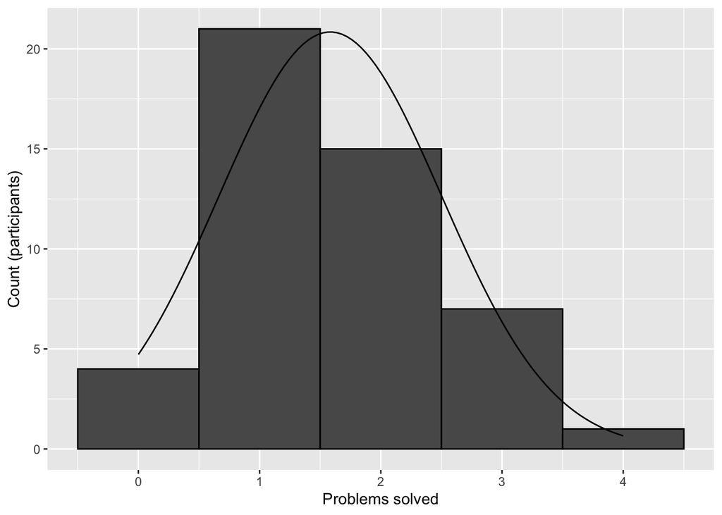

```r
n_obs = sum(!is.na(data$problems))
bw = 1
mean <- mean(data$problems)
sd <- sd(data$problems)

data %>% ggplot(aes(problems))  +
  geom_histogram(colour = "black", binwidth = bw) +
  stat_function(fun = function(x)
    dnorm(x, mean = mean, sd = sd) * bw * n_obs) +
  xlab('Problems solved') + ylab('Count (participants)')
```

## Scatterplot and best fit line, openness vs. problems solved

You learnt how to create a scatterplot and a best fit line in the regression worksheet.

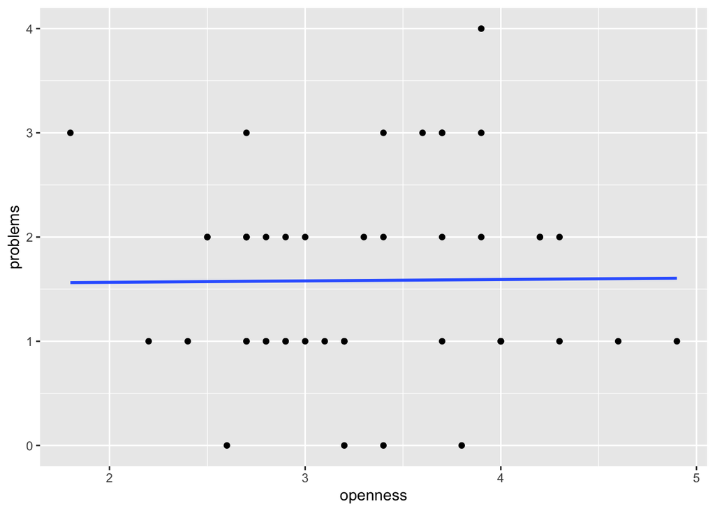

```r
data %>%
  ggplot(aes(openness, problems)) +
  geom_point() +
  geom_smooth(method=lm, se=F)
```

## Correlation between openness and problems solved

The researchers predicted that participants with more open personality types would be better at solving the problems. In other words, we should expect a positive correlation between openness and problem solving. We test a directional hypothesis with a one-tailed correlation. See the More on relationships, part 2. worksheet for more details.

```r
cor_o_problems<-cor.test(data$problems, data$openness, alternative='greater')
cor_o_problems
```

```
    Pearson's product-moment correlation

data:  data$problems and data$openness
t = 0.067585, df = 46, p-value = 0.4732
alternative hypothesis: true correlation is greater than 0
95 percent confidence interval:
 -0.2309906  1.0000000
sample estimates:
        cor
0.009964354
```

```r
# note that this is a 2-tailed test
library(BayesFactor)
cor_o_problems_bf<-correlationBF(data$problems, data$openness)
cor_o_problems_bf
```

```
Bayes factor analysis
--------------
[1] Alt., r=0.333 : 0.3249778 ±0%

Against denominator:
  Null, rho = 0
---
Bayes factor type: BFcorrelation, Jeffreys-beta*
```

**Explanation of commands:**

We use a Pearson correlation to look at the relationship between openness and the number of problems solved. We specify `alternative='greater'` to indicate that we are predicting a positive correlation (one-tailed test). We also calculate a Bayes factor to test the evidence for the correlation.

**Explanation of output:**

Contrary to the first hypothesis, there is no evidence for a positive correlation between openness and creative problem solving (*r* = 0.01, one-tailed, *BF* = 0.32).

## Correlation matrix: other personality factors and problems solved

Correlation matrices are covered in the Better tables worksheet.

```r
library(apaTables)
apa.cor.table(data %>% dplyr::select(conscientiousness:problems), filename='table1.doc', table.number = 1)
```

```
Table 1

Means, standard deviations, and correlations with confidence intervals


  Variable             M    SD   1           2           3           4
  1. conscientiousness 3.51 0.72

  2. extraversion      3.15 0.79 -.01
                                 [-.29, .28]

  3. agreeableness     4.36 0.46 .20         .43**
                                 [-.09, .46] [.17, .64]

  4. neuroticism       2.60 0.74 .28         .13         .07
                                 [-.00, .52] [-.16, .40] [-.22, .34]

  5. problems          1.58 0.92 -.12        -.19        .02         -.14
                                 [-.39, .17] [-.45, .10] [-.26, .30] [-.41, .15]


Note. M and SD are used to represent mean and standard deviation, respectively.
Values in square brackets indicate the 95% confidence interval.
The confidence interval is a plausible range of population correlations
that could have caused the sample correlation (Cumming, 2014).
 * indicates p < .05. ** indicates p < .01.
```

**Explanation of output:**

There were no correlations between the other four personality factors and problem solving. Note that these are 2-tailed correlations, as it’s not possible to specify 1-tailed tests with `apa.cor.table()`.

## Correlation between problems solved and flexible thinking

```r
cor_f_problems<-cor.test(data$problems, data$ftt, alternative='greater')
cor_f_problems
```

```
    Pearson's product-moment correlation

data:  data$problems and data$ftt
t = 2.118, df = 46, p-value = 0.0198
alternative hypothesis: true correlation is greater than 0
95 percent confidence interval:
 0.06214013 1.00000000
sample estimates:
      cor
0.2980887
```

```r
# note that this is a 2-tailed test
library(BayesFactor)
cor_f_problems_bf<-correlationBF(data$problems, data$ftt)
cor_f_problems_bf
```

```
Bayes factor analysis
--------------
[1] Alt., r=0.333 : 2.172511 ±0%

Against denominator:
  Null, rho = 0
---
Bayes factor type: BFcorrelation, Jeffreys-beta*
```

## Correlation between problems solved and vividness

```r
cor_v_problems<-cor.test(data$problems, data$psiq, alternative='greater')
cor_v_problems
```

```
    Pearson's product-moment correlation

data:  data$problems and data$psiq
t = -0.19137, df = 46, p-value = 0.5755
alternative hypothesis: true correlation is greater than 0
95 percent confidence interval:
 -0.2667972  1.0000000
sample estimates:
        cor
-0.02820461
```

```r
# note that this is a 2-tailed test
library(BayesFactor)
cor_v_problems_bf<-correlationBF(data$problems, data$psiq)
cor_v_problems_bf
```

```
Bayes factor analysis
--------------
[1] Alt., r=0.333 : 0.3296407 ±0%

Against denominator:
  Null, rho = 0
---
Bayes factor type: BFcorrelation, Jeffreys-beta*
```

**Explanation of commands:**

As for Openness, we use Pearson correlations to look at the relationship between the number of problems solved, Flexible Thinking and Vividness. We specify `alternative='greater'` to indicate that we are predicting a positive correlation (one-tailed test). We also calculate a Bayes factor to test the evidence for the correlations.

**Explanation of output:**

There is evidence for a positive correlation between flexibility and creative problem solving (*r* = 0.3, one-tailed, *BF* = 2.17). There is no evidence for a positive correlation between imagery vividness and creative problem solving (*r* = -0.03, one-tailed, *BF* = 0.33).

## Pairs plot

Pairs plots are are covered in the Better graphs worksheet.

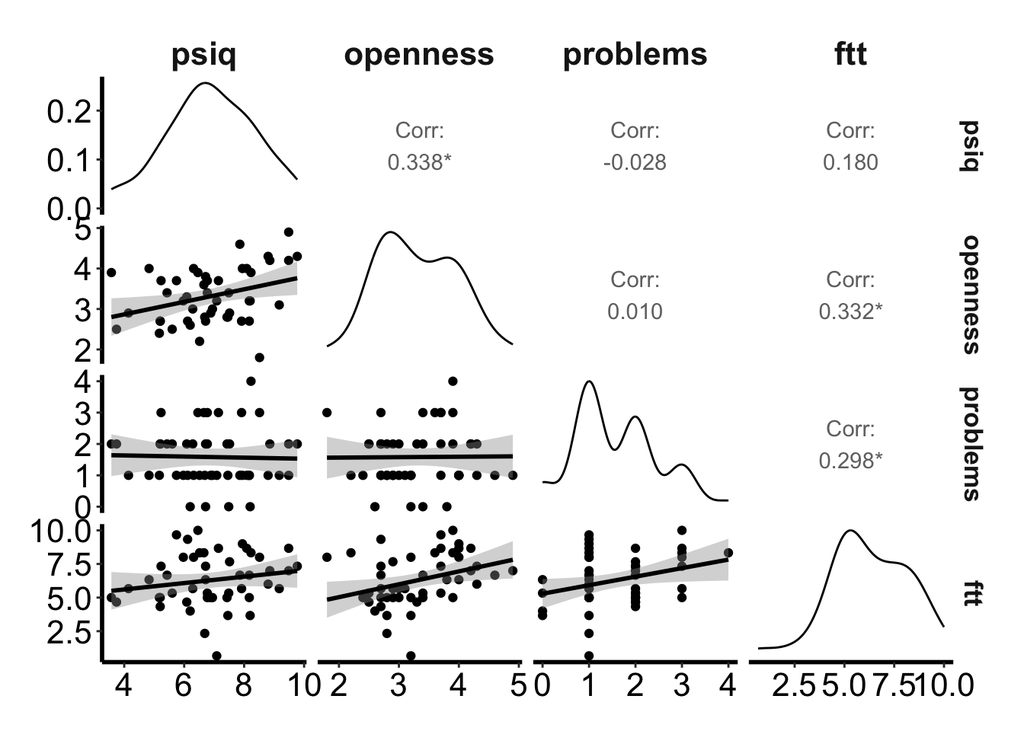

```r
library(GGally)
source('themeapa.R')
data %>%
  dplyr::select(psiq, openness, problems, ftt) %>%
  ggpairs(lower=list(continuous='smooth')) +
  theme_APA
```

## References

Andrade, J., May, J., Deeprose, C., Baugh, S.-J., & Ganis, G. (2014). [Assessing vividness of mental imagery: The Plymouth Sensory Imagery Questionnaire](https://onlinelibrary.wiley.com/doi/pdf/10.1111/bjop.12050?casa_token=-IMvMthFsKQAAAAA:_b6s7nwZ8JS-5fWM4Xxgey5sBBPpbIRPUupgZ2XFQ-jNYGNOK0ARomtRNgCIWUfZqUD7w9PBoLbeng) British Journal of Psychology, 105(4), 547–563.

Costa, P. T., & McCrae, R. R. (1992). Neo personality inventory-revised (NEO PI-R). Psychological Assessment Resources Odessa, FL.

May, J. (1987). The cognitive analysis of flexible thinking. Unpublished PhD thesis, University of Exeter.

This material is distributed under a [Creative Commons](https://creativecommons.org/) licence. CC-BY-SA 4.0.